# What makes a winning YC startup?

And has the formula changed?

Alibek Mamyrbay · Lawrence University Datathon

## The dataset

### What we built

- Scraped **5,880** companies across **46** batches that have started (through Spring 2026)
- Source: ycombinator.com/companies · **2005–2026**, 22 years
- Hit Algolia search index directly (`YCCompany_production`)
- Faceted by batch to bypass Algolia’s 1,000-result pagination cap
- Cleaned, joined, factored in R (`tidyverse` + `httr2`)

### Status mix

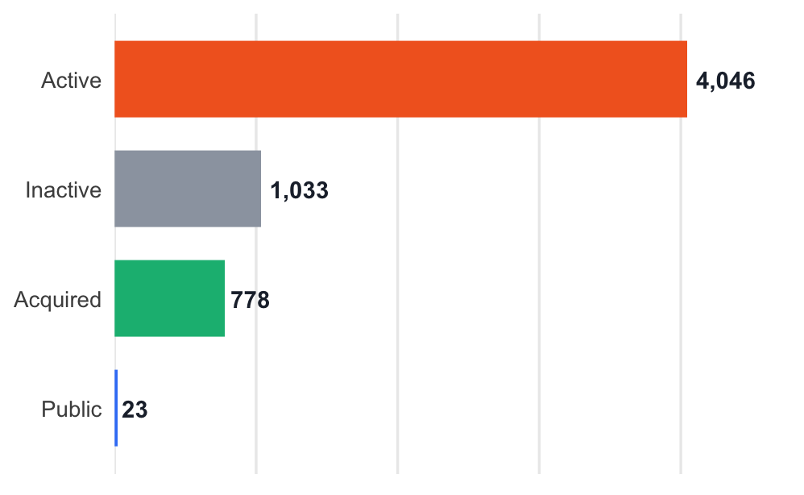

Source: ycombinator.com/companies, scraped May 07, 2026. Data is YC’s self-reported labels.

## Three questions

1What characteristics distinguish a **winning** YC startup?

2How has YC’s **portfolio evolved** over 20 years?

3Has the **recipe for success** changed?

“Winner” = reached **Acquired** or **Public** status. “Mature” = batch ≥5 years old (companies have had time to exit).

## Q1 · Fintech and B2B lead the exit hit rate

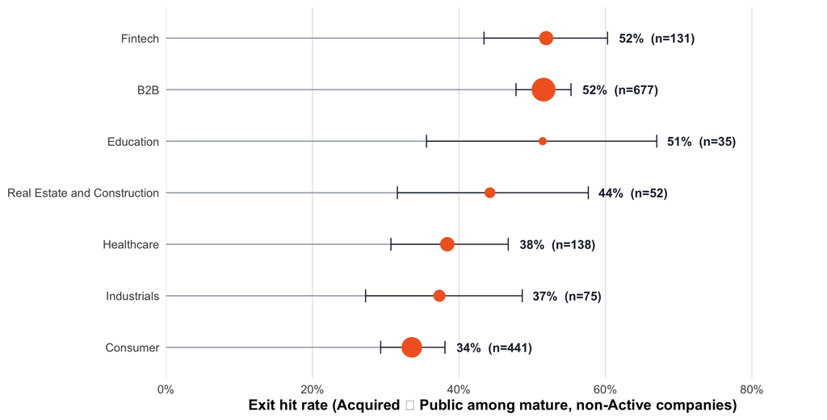

Among mature batches: Fintech and B2B both ~52%. Consumer drags the average — startups serving everyday users are fundamentally harder.

## Q1 · Survival is a function of size — but size is also an outcome

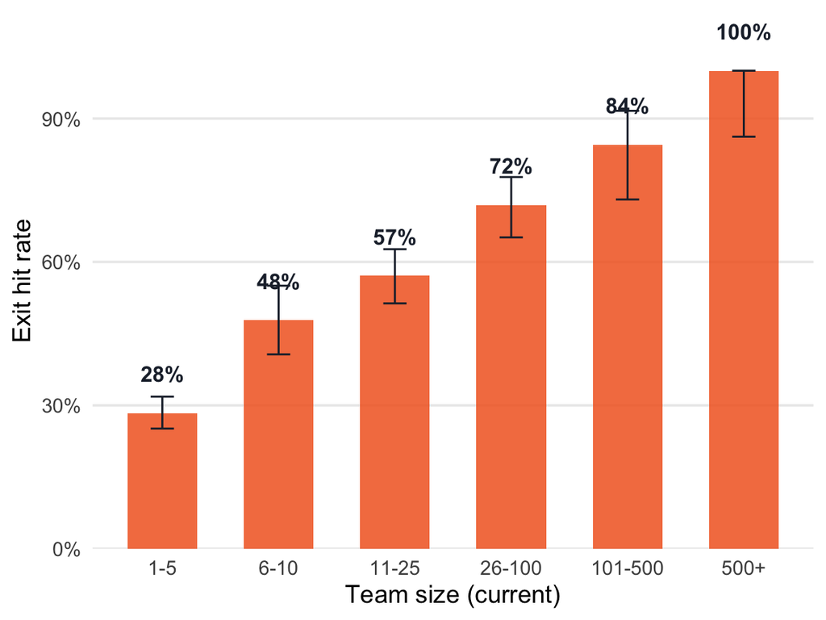

### Controlling for everything: **team size still wins**

Logit of **Successful vs Failed** on industry, region, team-size bucket, and era:

- 26–100 employees vs 1–5: **7.1×** higher odds (p<0.001)
- 101–500 vs 1–5: **14.7×** (p<0.001)
- USA vs Non-US: **1.3×** (n.s.) — geography barely matters
- 2015–2021 vs 2005–2014: **0.71×** (p=0.013)

## Q2 · B2B has eaten YC. Consumer has lost the throne.

[interactive chart not shown]

2010: Consumer ~35% of batch. 2024: barely 10%. The post-mobile gold rush is over; B2B SaaS now defines YC.

## Q2 · YC has gone global

[interactive chart not shown]

Top non-US: India (190), UK (161), Canada (133), Mexico (79). Once a Bay Area club, YC is now a global accelerator.

## Q3 · The 2010s playbook stopped paying off

[interactive chart not shown]

Every industry’s hit rate dropped from 2005–2014 to 2015–2021. Consumer fell hardest (38% → 29%) — even controlling for batch maturity. The 2010s really were special.

## Findings, in one slide

### 1. Industry matters less than you think

Fintech (52%) ≈ B2B (52%). Consumer (34%) is the loser. After controlling for size & era, raw industry effects shrink.

### 2. Geography barely matters

Non-US success rate is **45%** vs USA **46%**. The “you must be in the Bay Area” myth is dead — at least for clearing the YC bar.

### 3. The era effect is real

Mature 2015–2021 batches exit at **0.71×** the rate of 2005–2014, controlling for everything else. The 2010s were a uniquely fertile decade.

## Limitations & ethics

### Methodological caveats

- **Survivorship bias:** YC may de-emphasize Inactive companies — true failure rate could be higher
- **Censoring:** “exit hit rates” exclude still-active companies; recent batches still have time to surprise
- **Self-reported labels:** Status, industry, team size are YC’s classification, not audited
- **500+ team bucket:** showed perfect separation in the regression (100% success) — excluded from the model

### Sustainability & ethics

- Public Algolia API only — no scraping behind auth walls
- 1 request/second rate limit, identifying User-Agent
- No PII beyond what YC already publishes
- Dataset published alongside this deck for verification & reuse
- Source: ycombinator.com/companies (scraped May 07, 2026)

## Thank you

# Questions?

Code + dataset + this deck shipped together.

Built in R with `httr2`, `tidyverse`, `ggplot2`, `plotly`, `reactable`, `revealjs`.